# Outgroup Avoidance in Online Dating

Evidence from a Field Experiment

Lennard Naumann

WZB Berlin Social Science Center, Humboldt University Berlin

June 18, 2026  
EPSS Annual Conference

## Summary

*Question:* **Can brief, naturalistic video interventions reduce ethnic outgroup avoidance in online dating?**

*Design:* Preregistered **field RCT (*N = 1,000*)** on Berlin-based majority group users of a European dating platform; three theory-driven video treatments targeting ingroup norms, meta-prejudice, and intergroup commonality.

*Findings:* Outgroup avoidance reduced by **1.6 pp.** / **56%**, driven by Eastern European targets; ingroup norms treatment descriptively largest.

*Implications:* Simple interventions lead to meaningful shift; less entrenched avoidance easier to move.

## Online dating and outgroup avoidance

- *Avoidance* possible reason for muted contact effects (Paluck et al. 2021; Lowe 2025)
- Online dating characterized by ethnic homophily (Hitsch, Hortaçsu, and Ariely 2010; Anderson et al. 2014) and hierarchy (Potârcă and Mills 2015; Lewis 2016)
- Little evidence on avoidance *drivers* (Kauff et al. 2021) or habit rupture interventions (Paolini et al. 2026)
- Hypotheses: Avoidance is reduced by perceived
  - *(H1)* Ingroup norms regarding contact
  - *(H2)* Outgroup openness to contact (Meta-prejudice)
  - *(H3)* Intergroup commonality

## Study protocol

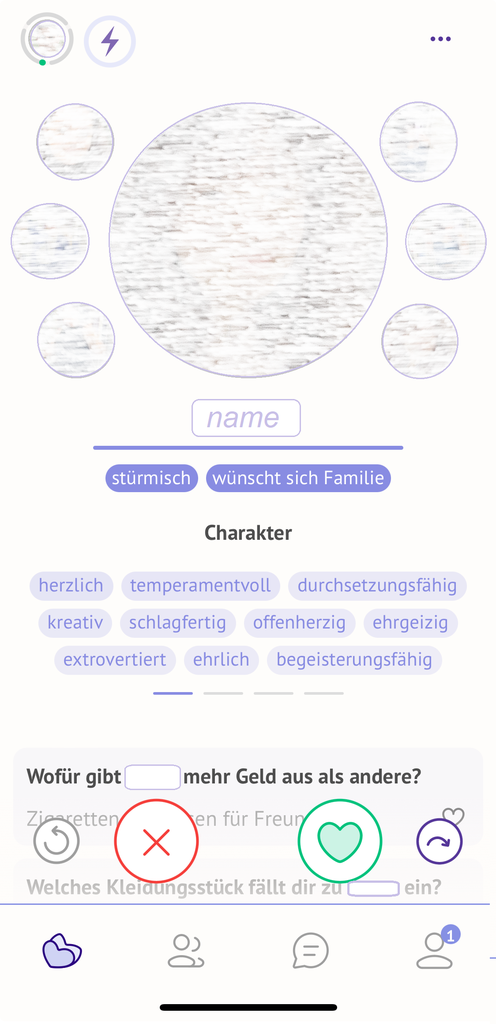

- ~80,000 active monthly users, mostly German
- Networked character: users swipe for friends
- Sample: 1,000 Berlin-based Native users, 14 days
- Treatment at t = 7, survey two days later

## Treatments

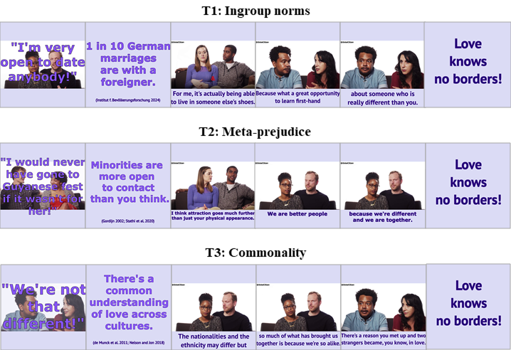

## Analysis

**Outcomes:**

- Behavior: Swiping bias (like rate difference) between outgroup and ingroup profiles
- Survey indexes: Contact preference (3), intention (2), and behavior (2 items); overall factor

**Estimands:**

- ATE in the week (behavior) / two days (survey) after treatment
- Heterogeneous effects by swiping target identity

## Main results

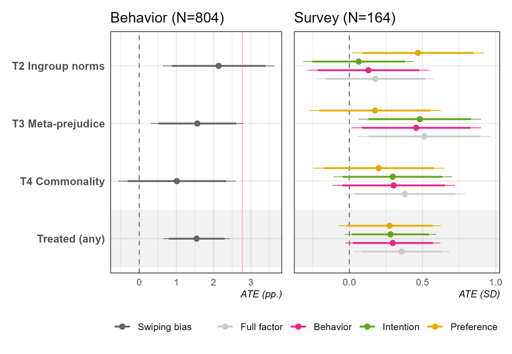

## Results by target group

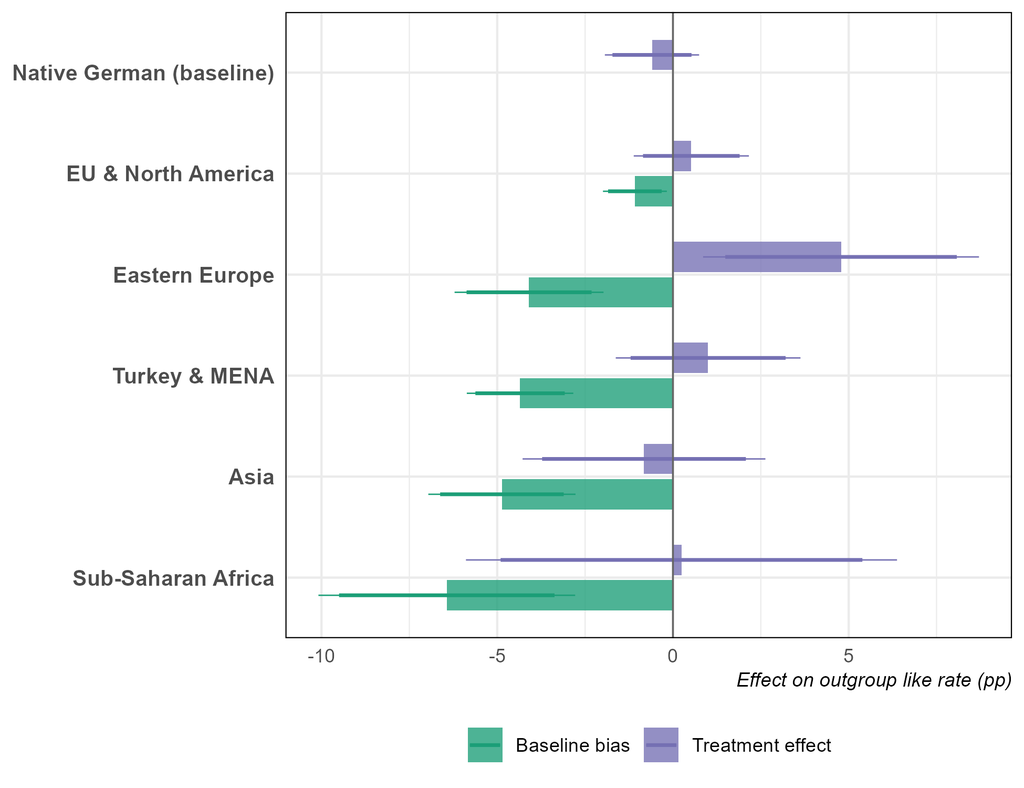

## Conclusions

- 1.6 pp. avoidance reduction (from baseline of 2.8 pp.) through targeted videos
- Driven by evaluations of Eastern European profiles
- Tentative evidence for norms as drivers
- Limitations: Liberal sample, no placebo
- Next steps: Treatment uptake analysis, longterm effects, descriptive survey

## References

Anderson, Ashton, Sharad Goel, Gregory Huber, Neil Malhotra, and Duncan Watts. 2014. “Political Ideology and Racial Preferences in Online Dating.” *Sociological Science*, 28–40. https://doi.org/10.15195/v1.a3.

Hitsch, Günter J., Ali Hortaçsu, and Dan Ariely. 2010. “What Makes You Click?—Mate Preferences in Online Dating.” *Quantitative Marketing and Economics* 8 (4): 393–427. https://doi.org/10.1007/s11129-010-9088-6.

Kauff, Mathias, Marta Beneda, Stefania Paolini, Michał Bilewicz, Patrick Kotzur, Alexander W. O’Donnell, Clifford Stevenson, Ulrich Wagner, and Oliver Christ. 2021. “How Do We Get People into Contact? Predictors of Intergroup Contact and Drivers of Contact Seeking.” *Journal of Social Issues* 77 (1): 38–63. https://doi.org/10.1111/josi.12398.

Lewis, Kevin. 2016. “Preferences in the Early Stages of Mate Choice.” *Social Forces* 95 (1): 283–320. https://doi.org/10.1093/sf/sow036.

Lowe, Matt. 2025. “Has Intergroup Contact Delivered?” *Annual Review of Economics* (Forthc.) (April). https://doi.org/10.1146/annurev-economics-081324-091109.

Paluck, Elizabeth Levy, Roni Porat, Chelsey S. Clark, and Donald P. Green. 2021. “Prejudice Reduction: Progress and Challenges.” *Annual Review of Psychology* 72 (1): 533–60. https://doi.org/10.1146/annurev-psych-071620-030619.

Paolini, Stefania, John Dixon, Patrick F. Kotzur, Maria-Therese Friehs, Chloe Bracegirdle, Aaron Lauterbach, Julia Köbrich, et al. 2026. “Towards a Habit-Rupture Model of Intergroup Contact in Everyday Settings.” *Nature Reviews Psychology*, January. https://doi.org/10.1038/s44159-025-00523-0.

Potârcă, Gina, and Melinda Mills. 2015. “Racial Preferences in Online Dating Across European Countries.” *European Sociological Review* 31 (3): 326–41. https://doi.org/10.1093/esr/jcu093.

## Appendix

## Analysis

- Behavioral outcome model:
  - $\mathrm{swipe}_{i,t}^{(d)} = \beta_1 \mathrm{outgr}_t \times T_{i,d} + \beta_2 \mathrm{outgr}_t + \beta_3 \mathrm{T}_{i,d} + \gamma_d + \delta_i$
- Survey outcomes regressed on treatment indicator and randomization block

## Treatment (H1: Ingroup norms)

[video not shown]

## Treatment H2: Outgroup openness

[video not shown]

[video not shown]

## Survey outcomes

- Outgroup contact preference: First principal component of the survey items
  - E4.1: The platform’s user base should be more diverse.
  - E4.5: I enjoy living in a multicultural environment.
  - E4.6: I (would) prefer being in a relationship with someone of the same ethnicity as me.
- Outgroup contact intention: First principal component of the survey items
  - D2.2, D2.4: In the next days, I intend to have contact with (someone from a different country, someone speaking a different language)
- Reported outgroup contact behavior: First principal component of the survey items
  - D3.2, D3.4: In the past days, I had contact with (someone from a different country, someone speaking a different language).

## Balance

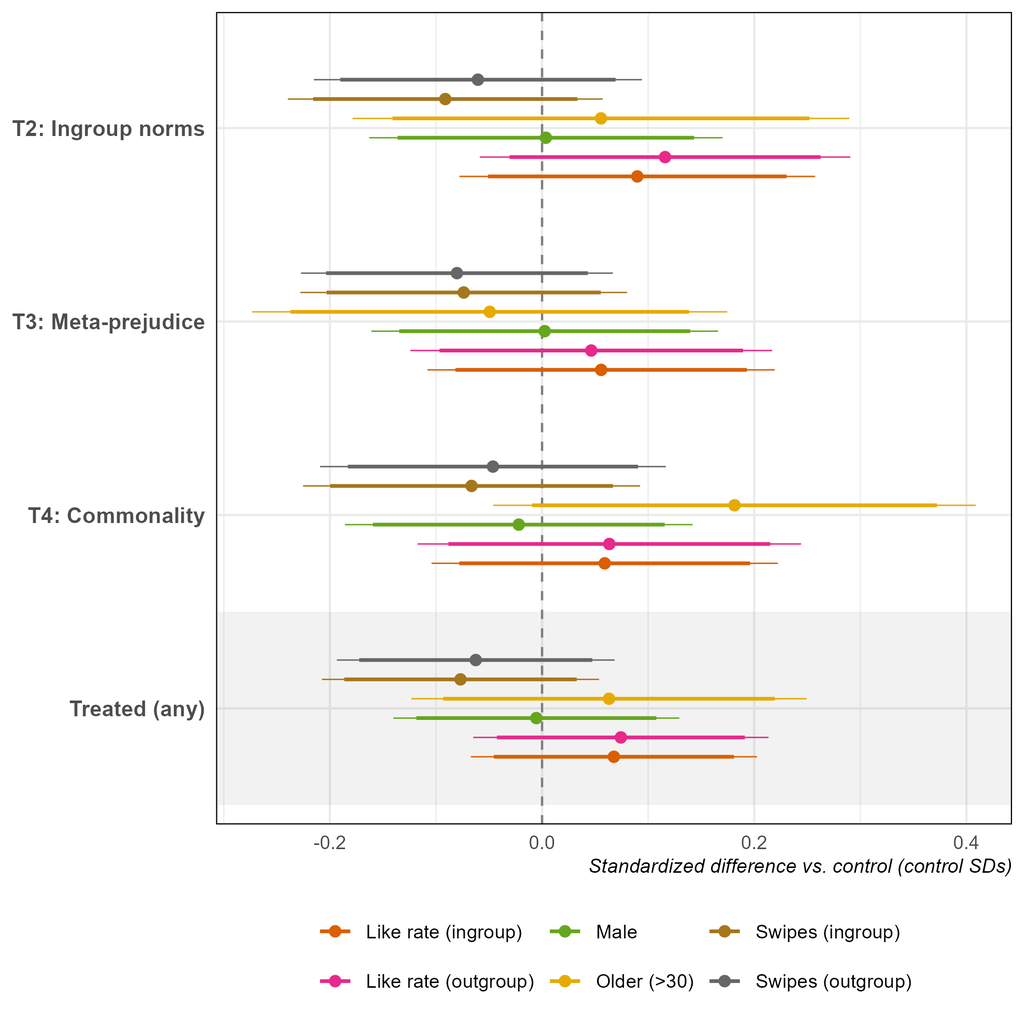

## Descriptive like rates by treatment conditions

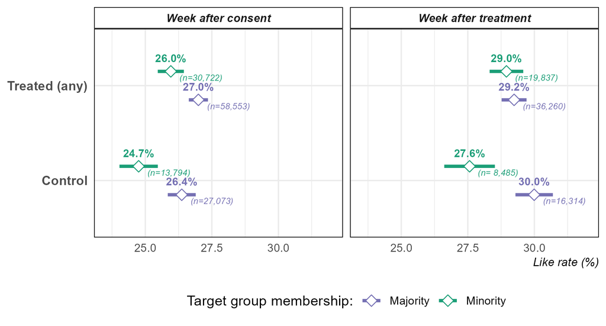

## Study protocol

[output not shown]

## Attrition

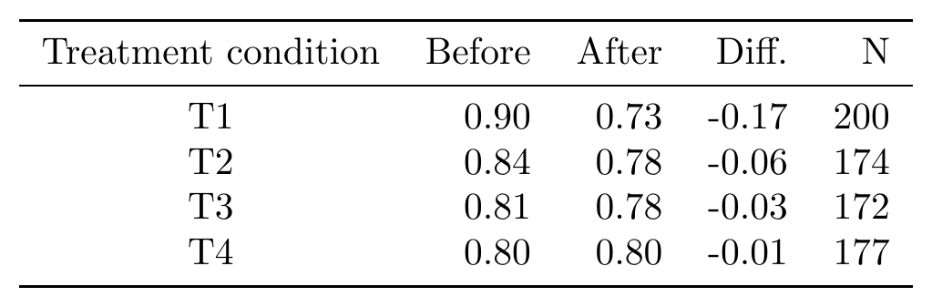

## Descriptive statistics

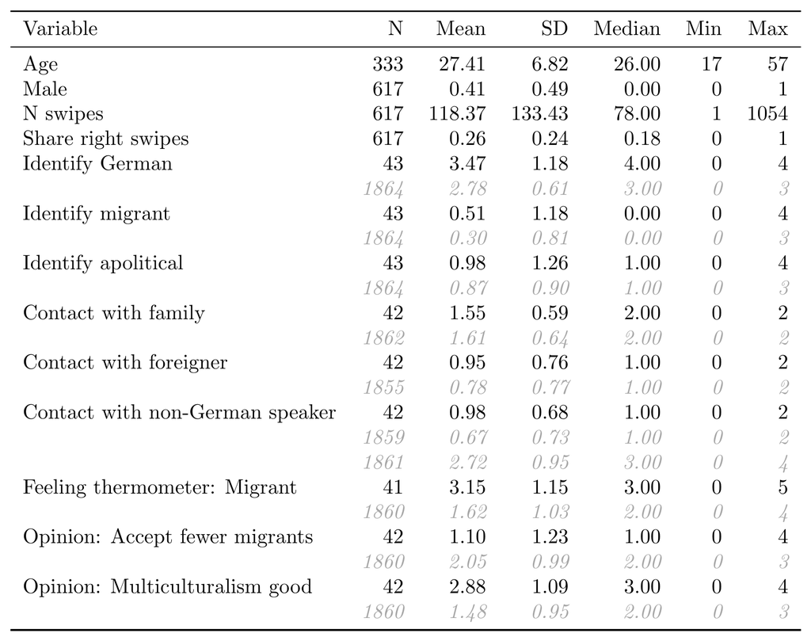

## Regression table: main results I

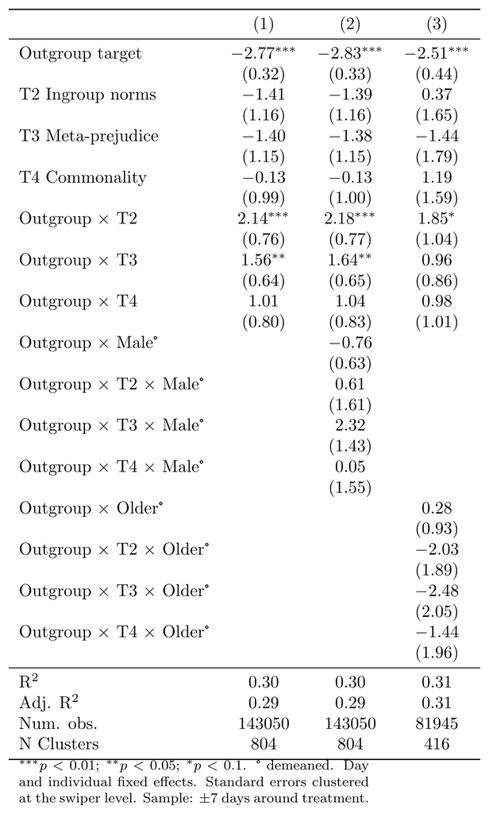

## Regression table: main results II

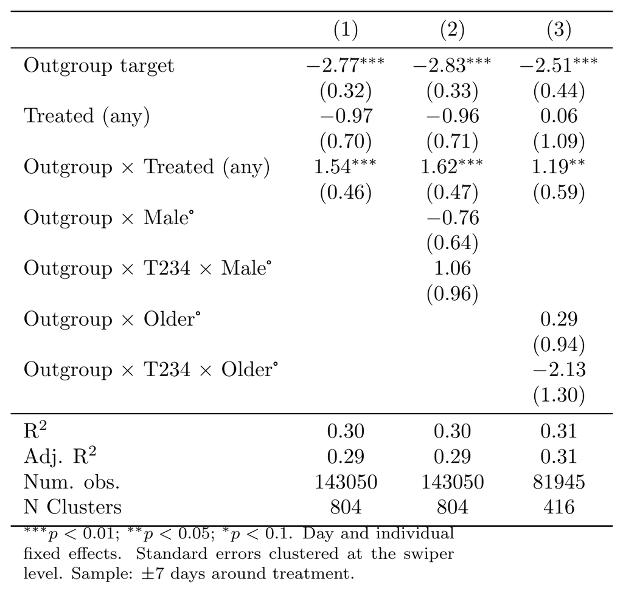

## Regression table: by target group

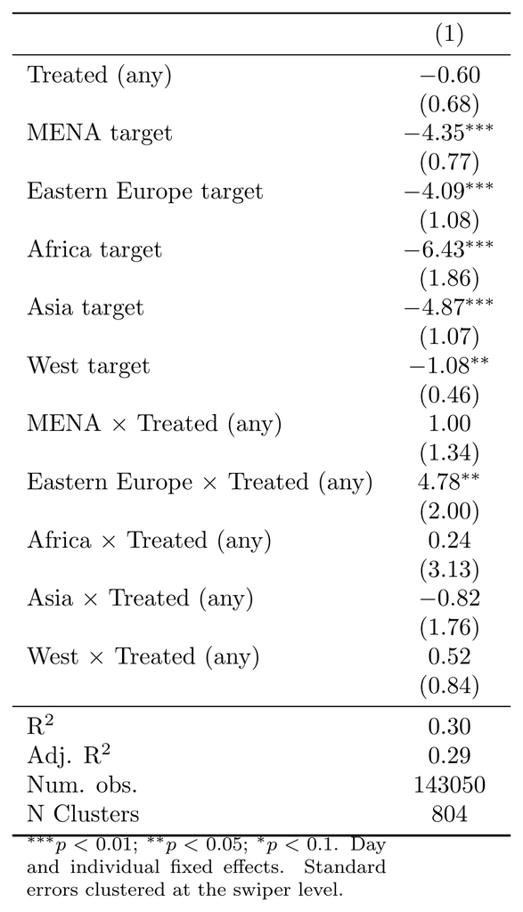

## Regression table: spillovers

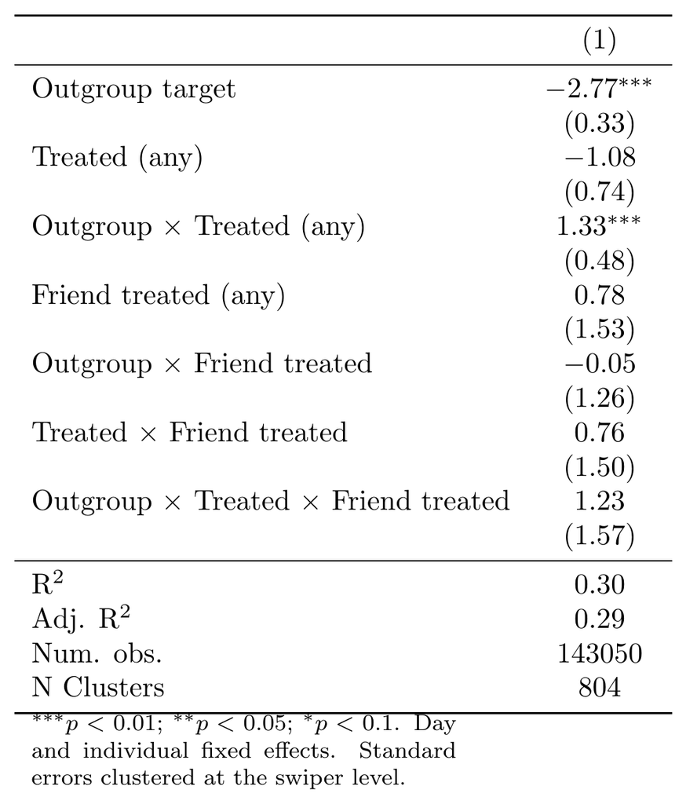

## Regression table: treatment decay

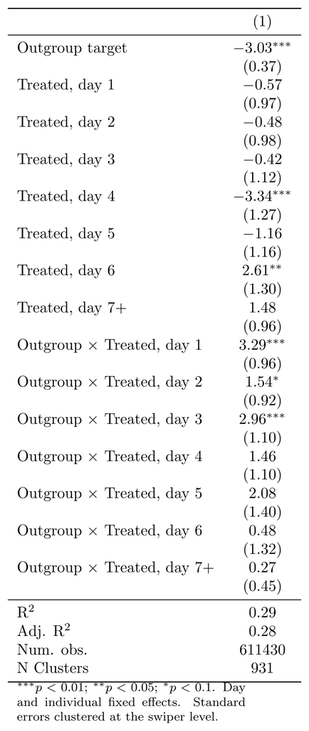

## Regression table: survey results I

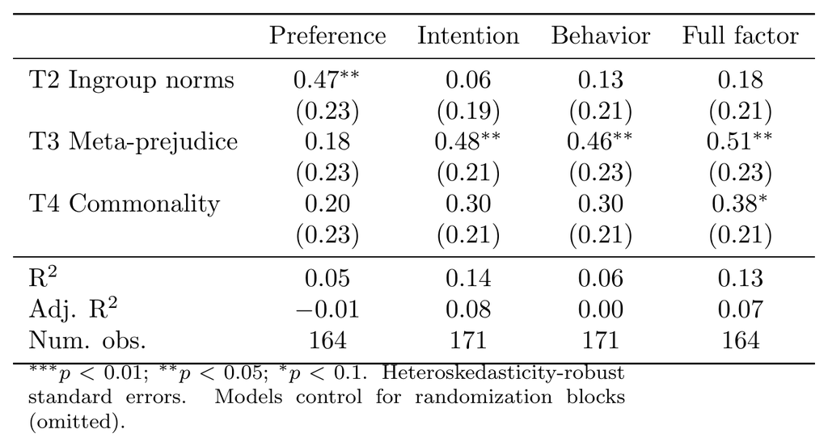

## Regression table: survey results I()

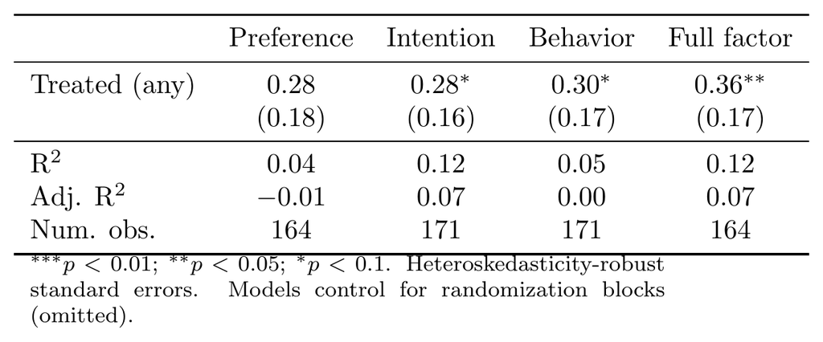